# Data 608- homework1

Santosh Manjrekar

September 15, 2019

```r
#install.packages("ggplot2")
library(ggplot2)
library(dplyr)
#library(gcookbook)
```

**Principles of Data Visualization and Introduction to ggplot2**

I have provided you with data about the 5,000 fastest growing companies in the US, as compiled by Inc. magazine. lets read this in:

```r
inc<- read.csv("https://raw.githubusercontent.com/charleyferrari/CUNY_DATA_608/master/module1/Data/inc5000_data.csv", stringsAsFactors = F)
```

And lets preview this data:

```r
head(inc)
```

```
##   Rank                         Name Growth_Rate   Revenue
## 1    1                         Fuhu      421.48 1.179e+08
## 2    2        FederalConference.com      248.31 4.960e+07
## 3    3                The HCI Group      245.45 2.550e+07
## 4    4                      Bridger      233.08 1.900e+09
## 5    5                       DataXu      213.37 8.700e+07
## 6    6 MileStone Community Builders      179.38 4.570e+07
##                       Industry Employees         City State
## 1 Consumer Products & Services       104   El Segundo    CA
## 2          Government Services        51     Dumfries    VA
## 3                       Health       132 Jacksonville    FL
## 4                       Energy        50      Addison    TX
## 5      Advertising & Marketing       220       Boston    MA
## 6                  Real Estate        63       Austin    TX
```

```r
summary(inc)
```

```
##       Rank          Name            Growth_Rate         Revenue
##  Min.   :   1   Length:5001        Min.   :  0.340   Min.   :2.000e+06
##  1st Qu.:1252   Class :character   1st Qu.:  0.770   1st Qu.:5.100e+06
##  Median :2502   Mode  :character   Median :  1.420   Median :1.090e+07
##  Mean   :2502                      Mean   :  4.612   Mean   :4.822e+07
##  3rd Qu.:3751                      3rd Qu.:  3.290   3rd Qu.:2.860e+07
##  Max.   :5000                      Max.   :421.480   Max.   :1.010e+10
##
##    Industry           Employees           City
##  Length:5001        Min.   :    1.0   Length:5001
##  Class :character   1st Qu.:   25.0   Class :character
##  Mode  :character   Median :   53.0   Mode  :character
##                     Mean   :  232.7
##                     3rd Qu.:  132.0
##                     Max.   :66803.0
##                     NA's   :12
##     State
##  Length:5001
##  Class :character
##  Mode  :character
##
##
##
##
```

Think a bit on what these summaries mean. Use the space below to add some more relevant non-visual exploratory information you think helps you understand this data:

I asked following questions and tried to answer them by plotting the graphs

Lets use the catterplot to see the growthrate distribution for the companies. Looks like most of the companies have growth rate below 10.

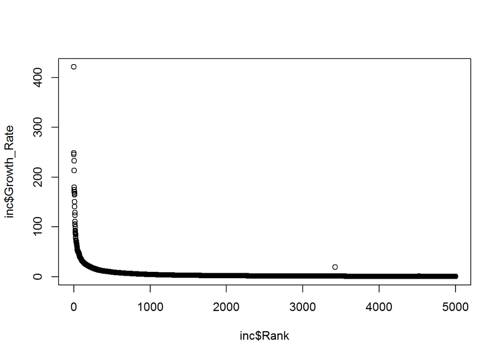

```r
plot(inc$Rank, inc$Growth_Rate)
```

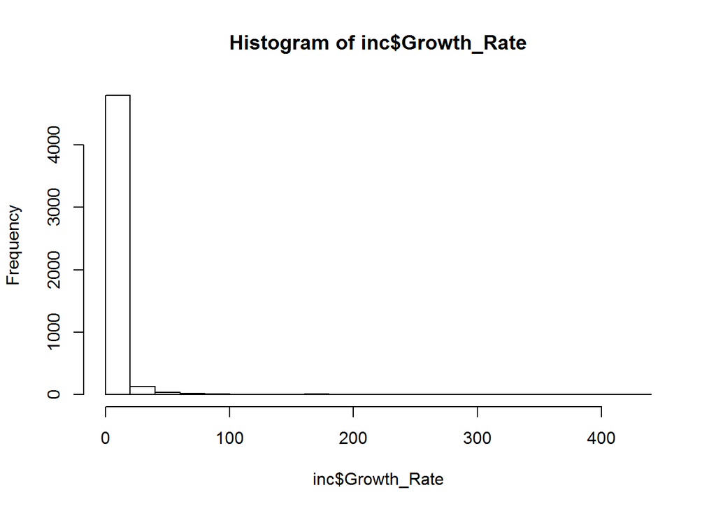

```r
hist(inc$Growth_Rate,breaks=20)
```

Is there any relationship betwen company revenue and company growth rate Looks like no relationship

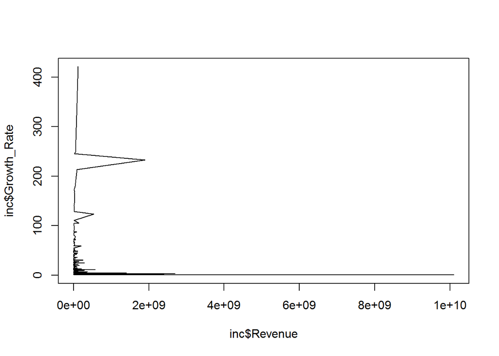

```r
plot(inc$Revenue,inc$Growth_Rate, type="l")
```

Let’s see the no of companies per state Looks like california has most no of companies

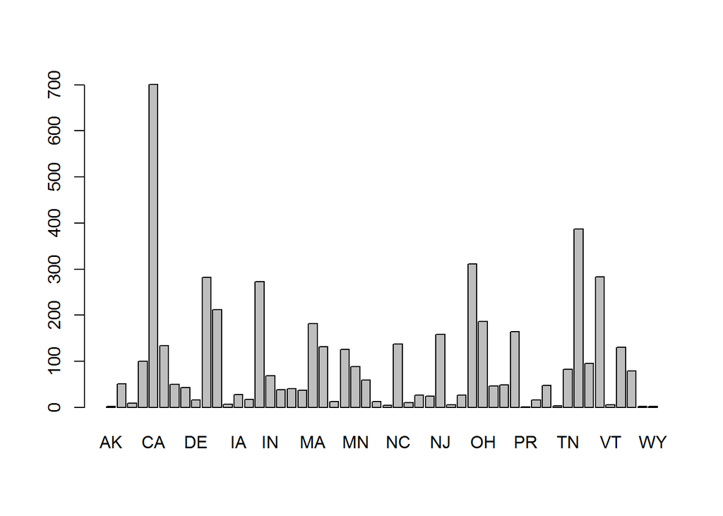

```r
barplot(table(inc$State))
```

## Question 1

Create a graph that shows the distribution of companies in the dataset by State (ie how many are in each state). There are a lot of States, so consider which axis you should use. This visualization is ultimately going to be consumed on a ‘portrait’ oriented screen (ie taller than wide), which should further guide your layout choices.

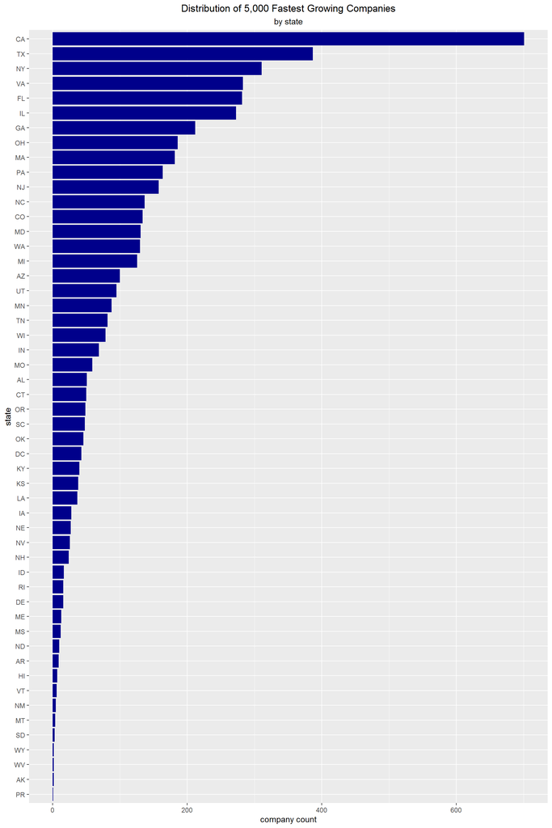

```r
require(ggplot2)
# Answer Question 1 here
# summarize raw data
state_summary <- inc %>%
  group_by(State) %>%
  tally() %>%
  rename(count = n) %>%
  arrange(desc(count))
# plot data
g <- ggplot(state_summary, aes(x = reorder(State, count), y = count))
g <- g + geom_bar(stat = "identity", fill = 'darkblue') + coord_flip()
g <- g + ggtitle("Distribution of 5,000 Fastest Growing Companies")
g <- g + labs(subtitle = "by state", x = "state", y = "company count")
g <- g + theme(plot.title = element_text(hjust = 0.5), plot.subtitle = element_text(hjust = 0.5))
g
```

## Quesiton 2

Lets dig in on the state with the 3rd most companies in the data set. Imagine you work for the state and are interested in how many people are employed by companies in different industries. Create a plot that shows the average and/or median employment by industry for companies in this state (only use cases with full data, use R’s `complete.cases()` function.) In addition to this, your graph should show how variable the ranges are, and you should deal with outliers.

```r
# Answer Question 2 here
# find state with third most companies (3rd row b/c already ordered desc)
third_state <- state_summary[3,"State"]
third_state
```

```
## # A tibble: 1 x 1
##   State
##   <chr>
## 1 NY
```

```r
# filter original data: complete cases and 3rd ranked state only
third_data <- inc[complete.cases(inc),] %>%
  inner_join(third_state, by = "State")

# find mean employees by industry
means <- aggregate(Employees ~ Industry, third_data, mean)

# find maximum average employee no.
means_max <- max(means$Employees)

# prepare plot data: box plots (with outliers removed) to show variation; dots for mean EEs
g <- ggplot(third_data, aes(x = reorder(Industry,Employees,mean), y = Employees))
g <- g + geom_boxplot(outlier.shape = NA, show.legend=F) + coord_flip()
g <- g + labs(x = "industry", y = "employees", title="Mean Employee Size by Industry")
g <- g + labs(subtitle = "with boxplots")
g <- g + geom_point(data = means, aes(x=Industry, y=Employees), color='darkblue', size = 2)
g <- g + theme(plot.title = element_text(hjust = 0.5), plot.subtitle = element_text(hjust = 0.5))
```

Let’s look at the plot in its current format

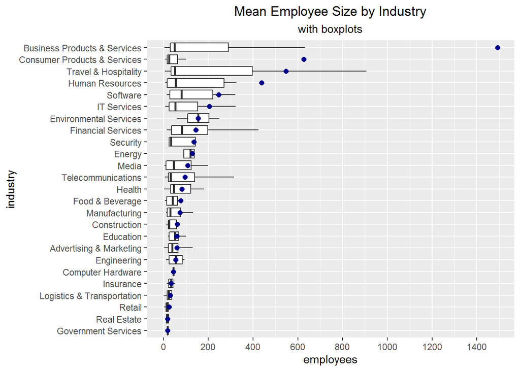

```r
# plot data, linear scale
g <- g +  scale_y_continuous(limits = c(0,means_max), breaks = seq(0, means_max, 200))
g
```

The plot above indicates that the mean data are highly skewed: the average employee count in the Business Products & Services industry are roughly 140% times greater than the second ranked industry, Consumer Products & Services.

Given this significant skew, it may be helpful to visualize the employee count data on a logarithmic scale:

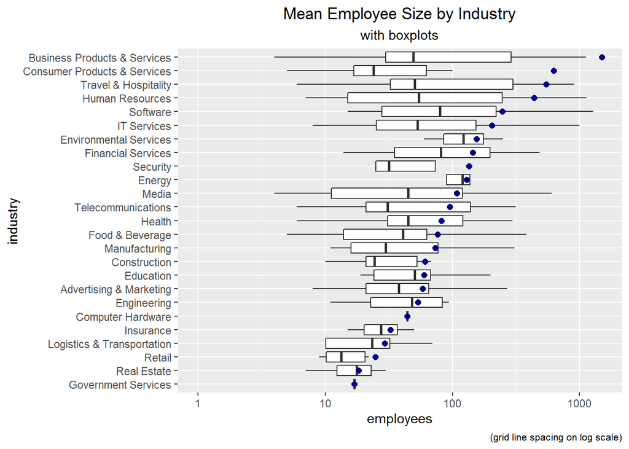

```r
# plot data, log scale
g <- g + scale_y_log10(limits = c(1, means_max))
g <- g + labs(caption = "(grid line spacing on log scale)")
g <- g + theme(plot.caption = element_text(size = 8))
g
```

## Question 3

Now imagine you work for an investor and want to see which industries generate the most revenue per employee. Create a chart that makes this information clear. Once again, the distribution per industry should be shown.

```r
# revenue per employee by industry
revenue <- inc[complete.cases(inc),] %>%
  group_by(Industry) %>%
  summarise(org_count = n(),Revenue = sum(Revenue),Employees= sum(Employees)) %>%
  mutate(rev_ee = Revenue / Employees )

# maximum rev/ee
max_rev_ee = max(revenue$rev_ee)
```

First, lets plot the data using color shading to indicate the total number of employees in a given industry.

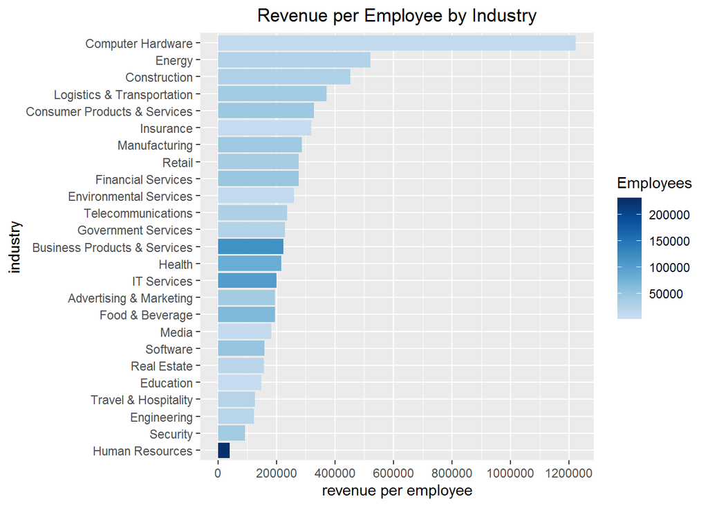

```r
# plot with color fill by employee count
g <- ggplot(revenue, aes(x=reorder(Industry, rev_ee), y=rev_ee, fill=Employees))
g <-  g + geom_bar(stat="identity") + coord_flip()
g <- g + labs(title = "Revenue per Employee by Industry", x = "industry", y = "revenue per employee")
g <- g + scale_fill_gradientn(colours = blues9[-(1:2)])
g <- g + theme(plot.title = element_text(hjust = 0.5))
g <- g + scale_y_continuous( breaks=seq(0,max_rev_ee,200000))
g
```

Now let’s plot using shading to indicate the count of unique organizations in a given industry:

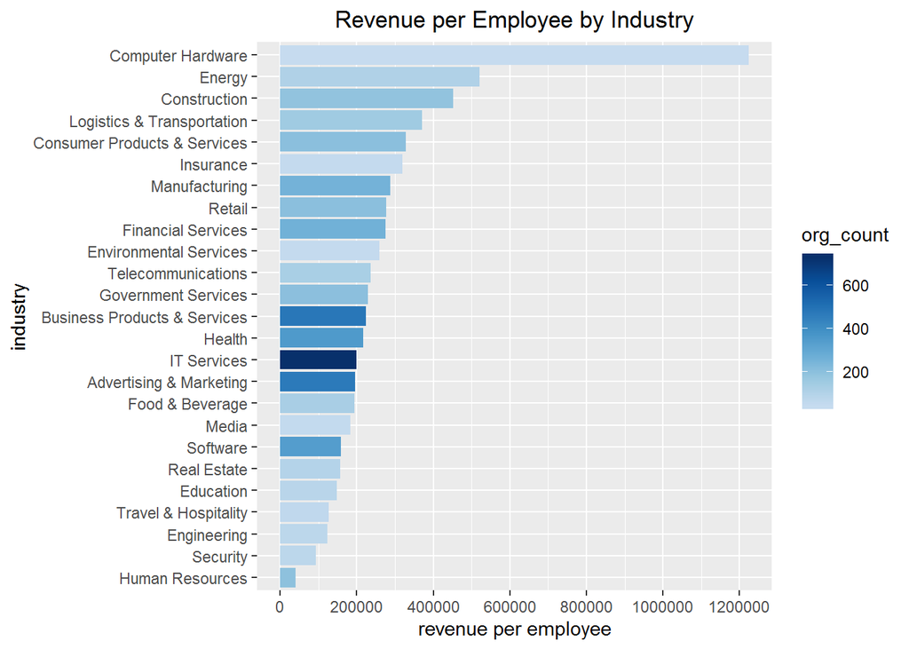

```r
# plot with color fill by org count
g <- ggplot(revenue, aes(x=reorder(Industry, rev_ee), y=rev_ee, fill=org_count))
g <- g + geom_bar(stat="identity") + coord_flip()
g <- g + labs(title = "Revenue per Employee by Industry", x = "industry", y = "revenue per employee")
g <- g + scale_fill_gradientn(colours = blues9[-(1:2)])
g <- g + theme(plot.title = element_text(hjust = 0.5),plot.subtitle = element_text(hjust = 0.5))
g <- g + scale_y_continuous( breaks=seq(0,max_rev_ee,200000))
g
```